# Basics of Quarto

Author

Ambra Perugini

# What to expect from this workshop

- To get a basic understanding of quarto syntax
- Learn how to integrate code to text and set up chunks
- A bit of formatting for beginners
- Be able to create a complete report and a presentation

# Key feauters of Quarto

- Reproducible
- Integrated
- Flexible
- Promotes collaboration

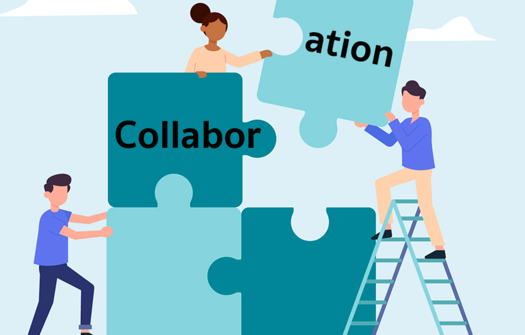

## Main feauters

- It supports different languages: R, Python, Julia, ObservableJS and more
- It allows cross-referencing of equations, tables, images
- All the meta-data is tidily organized in the YAML
- With a single file you can create more output formats:
- `html_document`
- `pdf_document`
- `word_document`
- `revealjs`
- `pptx`
- `beamer`
- You can also create projects such as books, websites, blogs

## Impostazione di un progetto in RStudio

1. Open **RStudio** and go to `File -> New Project`
2. Choose **New Directory** and then `Quarto Project` (or Quarto book, Quarto website, ecc.)
3. Choose where to setup your new folder
4. Click **Create Project**

**ALL SET**

# Structure of a Quarto file (.qmd)

## YAML

It’s the initial chunk that defines all meta-data and file formatting:

- author: “My Name”
- title: “My beaurtiful title”
- subtitle: “A beautiful subtitle”
- date: can be set to system date
- abstract: “a long text of my abstract”
- toc: true (table of content)
- toc-title: Contents
- toc-location: left
- number-sections: true
- embed-resources: true (to be able to share your file with all embedded resources without sharing the entire folder)
- execute: here you can set up all your defoult chunk options
- cache: ture (it saves chunks outputs, useful to compile faster)
- results: hide (to hide chunk’s output, set to ‘markup’ to show output)
- echo: false (to not show chunk code)
- code-fold: true (to show chunk code by clicking on an icon)

es:

```yaml
---
title: "my html"
subtitle: "Very nice subtitle"
author: Your Name
date:
  format:
    html:
      toc: true
      toc-title: Contents
      toc-location: left
      number-sections: true
      embed-resources: true
      code-fold: true
execute:
  cache: true
  results: hide
  echo: false
---
```

## Document body

### Titles & Subtitles

```bash
# Main title

## Frist level subtitle

### Second level subtitle

#### Third level subtitle

This is an **example paragraph** with bold text.

*Italic* or `single spaced font` can be used as well.
```

This is an **example paragraph** with bold text.

*Italic* or `single spaced font` can be used as well.

Lists:

```bash
- Elements
```

- Elements

This is a note[^1]

And it’s done in the following way: `^[the note]` and you put it next to the text where you want the note number to appear

Here is a side note

```bash
::: aside

Here is a side note

:::
```

## Chunks

They are used to insert code and run analysis. A lot of options can be specified.

Example:

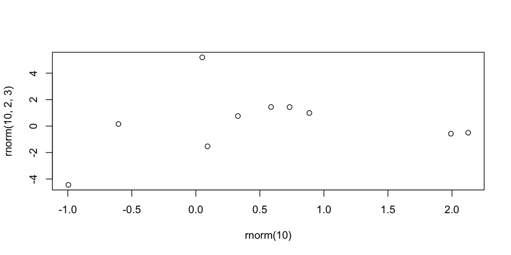

Figure 1: Caption of the figure.

````markdown
```{r}
#| code-fold: false
#| label: fig-name_of_figure
#| fig-width: 8
#| fig-height: 4
#| fig-cap: Caption of the figure.

plot(x = rnorm(10), y = rnorm(10,2,3))
```
````

You can put those parameters directly in your chunk.

## Equations

- Equations in a new row: `$$…$$`
- Inline equations `$…$`

`$$ Y = \beta_{0} + \beta_{1} X $$`

$$Y = \beta_{0} + \beta_{1} X$$

Easy shortcuts

1. To insert chunks `Ctrl + Alt + I` (Windows) `Cmd + Option + I` (Mac)
2. To execute code chunks, use `Ctrl + Enter` (Windows) o `Cmd + Enter` (Mac)
3. To generate the final output, click on `Render`

## Columns

Content 1:

- Point 1
- Point 2
- Point 3

Content 2:

- Point 1
- Point 2
- Point 3

```bash
:::: {.columns}

::: {.column width="50%"}


:::

::: {.column width="50%"}


:::

::::
```

## Colored text

I love Quarto!

```bash
I <span style="color:#ff4da6;">love</span> Quarto!
```

I am centered

```bash
::: {style="text-align: center;"}
I am centered
:::
```

I am bigger

```bash
::: {style="text-align: center; font-size: 2em;"}
I am bigger
:::
```

I am bigger and pink

```bash
::: {style="text-align: center; font-size: 2em; color: pink;"}
I am bigger and pink
:::
```

## CSS for more extensive style formatting

What is a CSS file?

- CSS (Cascading Style Sheets) is a programming language used to format an html document or revealjs.
- CSS files have the .css extension and they contain roules of style applicable to html elements.
- They allow to separate the content of your document from the formatting parts, improving code mantainance

You can insert it in the quarto file in the following way:

```bash
format:
  html:
    css: stile.css
```

**Tiny example** of what you could put in the file:

```bash
body {
  font-family: Arial, sans-serif;
  background-color: #f4f4f4;
}
h1 {
  color: darkred;
  text-align: center;
}
```

It is possible to create chunks to put CSS directly in Quarto:

````markdown
```{css}
h1 {
  color: black;
}

```
````

## Images

This is how to insert images

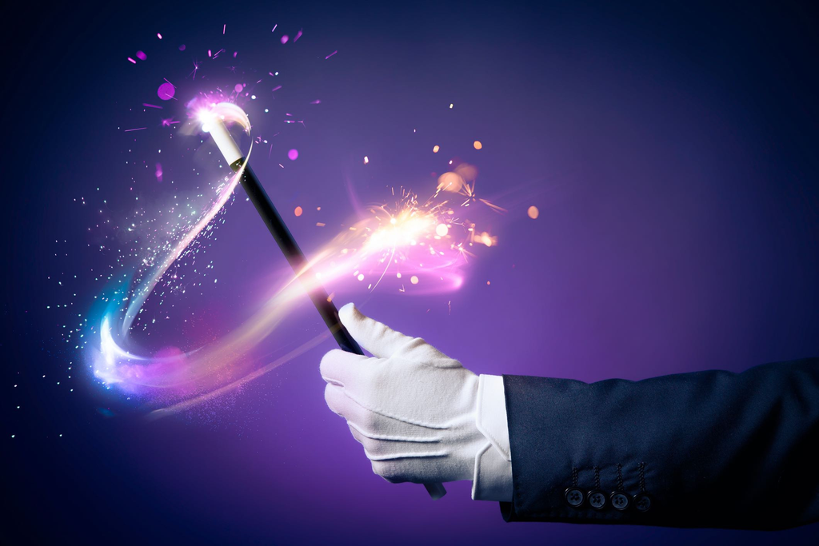

```markdown
![](figures/magic.png){fig-align="center"}
```

You can specify precisly the position, width and height:

`![](figures/letsgo.jpeg){.absolute bottom=0 right=50 width="300" height="300"}`

[figure not shown]

## Citations

You can add citations contained in your .bib file as follows Scheel et al. (2021), (Scheel et al., 2021).

```markdown
@scheel2021hypothesis to cite in text
[@scheel2021hypothesis] to cite between brakets
```

All the references are automatically put in a section at the end of your document. You can create a new .bib file by openinf a txt file and then saving it with the .bib extension. It is very important to specify in your **YAML** your file and it’s directory in the followinf way:

`bibliography: "my_bib.bib"`

The use of a csl file for APA formatting of citations is necessary to ensure the desired format and should also be specified in **YAML**:

`csl: "apa.csl"`

The csl file (Citation Style Language) that you can find in the repository allows to correctly format in APA style your citations.

## Values in text directly form r objects

````markdown
```{r}
library(readxl)
DATA <- read_xls(path = "data/Sara_dataset.xls")

cor_pre <- cor(DATA$anx_pre, DATA$mathquiz, use = "complete.obs")


cor_pre
```
````

```
[1] -0.05491077
```

- Correlation between Anxiety pre and math quiz -> $r =$ -0.0549108

```bash
- Correlation between Anxiety pre and math quiz -> $r =$ `\r cor_pre`
```

- -0.0549108

```bash
- `\r cor(DATA$anx_pre, DATA$mathquiz, use = "complete.obs")`
```

## Panels (visual)

**From data (code)**

```r
library(criticalESvalue)
library(psych)
library(psychTools)
data("holzinger.swineford")
Holz <- holzinger.swineford
tt <- t.test(Holz$t01_visperc [ Holz$female == 1], Holz$t01_visperc [ Holz$female == 2])
critical(tt)
```

**From data (output)**

```
    Welch Two Sample t-test

data:  Holz$t01_visperc[Holz$female == 1] and Holz$t01_visperc[Holz$female == 2]
t = 1.4095, df = 298.9, p-value = 0.1597
alternative hypothesis: true difference in means is not equal to 0
95 percent confidence interval:
 -0.06419229  0.38823118
sample estimates:
mean of x mean of y
 4.314090  4.152071

|== Effect Size and Critical Value ==|
d = 0.1623665 dc = ± 0.2269609 bc = ± 0.2262117
g = 0.1619587 gc = ± 0.2263909
```

**From sample size (code)**

```r
m1 <- 10
m2 <- 15
sd1 <- 5
sd2 <- 4.25
n <- 30
critical_t2sp(m1 = m1, m2 = m2, sd1 = sd1, sd2 = sd2, n = n)
```

**From sample size (output)**

```
$dz
[1] -0.7619393

$dzc
[1] 0.3734061

$d
[1] -1.077545

$dc
[1] 0.528076

$bc
[1] 2.450367

$se
[1] 1.198089

$df
[1] 29

$g
[1] -1.049394

$gc
[1] 0.51428

$gz
[1] -0.7420336

$gzc
[1] 0.3636509
```

## Panels (source)

```markdown
::: panel-tabset
### From data (code)
```

```r
#| echo: true
#| results: hide
#| code-fold: false

library(criticalESvalue)
library(psych)
library(psychTools)
data("holzinger.swineford")
Holz <- holzinger.swineford
tt <- t.test(Holz$t01_visperc [ Holz$female == 1], Holz$t01_visperc [ Holz$female == 2])
critical(tt)
```

```markdown
### From data (output)
```

```r
#| echo: false
#| results: markup

library(criticalESvalue)
library(psych)
library(psychTools)
data("holzinger.swineford")
Holz <- holzinger.swineford
tt <- t.test(Holz$t01_visperc [ Holz$female == 1], Holz$t01_visperc [ Holz$female == 2])
critical(tt)
```

```markdown
### From sample size (code)
```

```r
#| echo: true
#| results: hide
#| code-fold: false

m1 <- 10
m2 <- 15
sd1 <- 5
sd2 <- 4.25
n <- 30
critical_t2sp(m1 = m1, m2 = m2, sd1 = sd1, sd2 = sd2, n = n)
```

```markdown
### From sample size (output)
```

```r
#| echo: false
#| results: markup

m1 <- 10
m2 <- 15
sd1 <- 5
sd2 <- 4.25
n <- 30
critical_t2sp(m1 = m1, m2 = m2, sd1 = sd1, sd2 = sd2, n = n)
```

```markdown
:::
```

## Cross-references

They can be used for sections:

```bash
# Introduction {#sec-introduction}

See @sec-introduction for more informations.
```

For images:

```bash
![](fig.png){#fig-bho}

As shown in @fig-bho
```

Or tables:

```bash
| Col1 | Col2 | Col3 |
|------|------|------|
| A    | B    | C    |
| E    | F    | G    |
| A    | G    | G    |

: table description {#tbl-lettere}

See @tbl-lettere.
```

Or:

```bash
::: {#tbl-lettere}

| Col1 | Col2 | Col3 |
|------|------|------|
| A    | B    | C    |
| E    | F    | G    |
| A    | G    | G    |

Table description

:::

See @tbl-lettere.
```

For tables created in chunks:

```bash
#| label: tbl-iris
#| tbl-cap: "Iris Data"

library(knitr)
kable(head(iris))
```

## References

Scheel, A. M., Tiokhin, L., Isager, P. M., & Lakens, D. (2021). Why hypothesis testers should spend less time testing hypotheses. *Perspectives on Psychological Science*, *16*(4), 744–755.

## Footnotes

[^1]: that will be put at the end